# Report HW2

### 0656109 黃慎航

```python
import pandas as pd
import numpy as np
import matplotlib.pyplot as plt
from mpl_toolkits.mplot3d import Axes3D
from sklearn import cluster, metrics, decomposition


df = pd.DataFrame(pd.read_csv('201703_Taiwan_preprocessed.csv'))
df2 = df[(df['lon'] > 110) & (df['lat'] > 20) & (df['lat'] <25)]#only in Taiwan
```

# Task1 Spatial Clustering:

### Kmeans V.S DBSCAN

在Kmeans的部分，首先要決定cluster數量，利用silhouette_score找出適當的數量

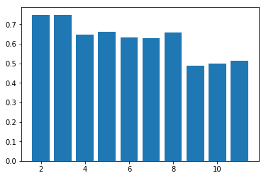

```python
df_location = df2.iloc[:,[8,9]].drop_duplicates()
silhouette_avgs = []
ks = range(2, 12)
for k in ks:
    kmeans_fit = cluster.KMeans(n_clusters = k).fit(df_location)
    cluster_labels = kmeans_fit.labels_
    silhouette_avg = metrics.silhouette_score(df_location, cluster_labels)
    silhouette_avgs.append(silhouette_avg)

# k = 2 到 10 的績效
plt.bar(ks, silhouette_avgs)
plt.show()
```

選擇cluster數為3(分群效果較佳）和10(分群效果較差），並測試分群計算時間。

```
CPU times: user 25.1 ms, sys: 3.02 ms, total: 28.1 ms
Wall time: 26 ms
CPU times: user 48.4 ms, sys: 336 µs, total: 48.7 ms
Wall time: 48.9 ms
```

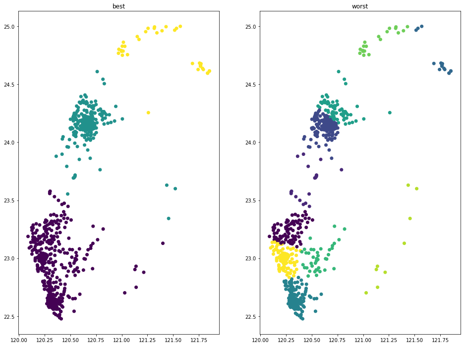

```
best:  0.746598904376
worst:  0.509447694464
```

```python
plt.figure(figsize=(16, 12))
kmeans1 = cluster.KMeans(n_clusters = 3, random_state = 0)
%time kmeans1.fit(df_location)
plt.subplot(121)
plt.scatter(df_location['lon'].values, df_location['lat'].values, c=kmeans1.labels_)
plt.title('best')

kmeans2 = cluster.KMeans(n_clusters = 10, random_state = 0)
%time kmeans2.fit(df_location)
plt.subplot(122)
plt.scatter(df_location['lon'].values, df_location['lat'].values, c=kmeans2.labels_)
plt.title('worst')
plt.show()

silhouette_avg1 = metrics.silhouette_score(df_location, kmeans1.labels_)
print('best: ',silhouette_avg1)
silhouette_avg2 = metrics.silhouette_score(df_location, kmeans2.labels_)
print('worst: ',silhouette_avg2)
```

可以明顯發現n=3分群效果比n=10來得好

接下來對DBSCAN做相似的步驟，此時找的並不是cluster數量而是DBSCAN的搜尋半徑大小

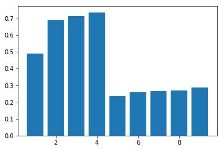

```python
silhouette_avgs = []
ep = range(1, 10)
for e in ep:
    BDSCAN_fit = cluster.DBSCAN(eps = float(e/20), min_samples = 10).fit(df_location)
    cluster_labels = BDSCAN_fit.labels_
    silhouette_avg = metrics.silhouette_score(df_location, cluster_labels)
    silhouette_avgs.append(silhouette_avg)

# eps = 0.05 到 0.5 的績效
plt.bar(ep, silhouette_avgs)
plt.show()
```

eps選擇0.2及0.25，兩者之間有極具落差，其原因是下面兩群被分類成一群

```
CPU times: user 11 ms, sys: 4.65 ms, total: 15.6 ms
Wall time: 11.7 ms
CPU times: user 7.33 ms, sys: 457 µs, total: 7.79 ms
Wall time: 7.8 ms
```

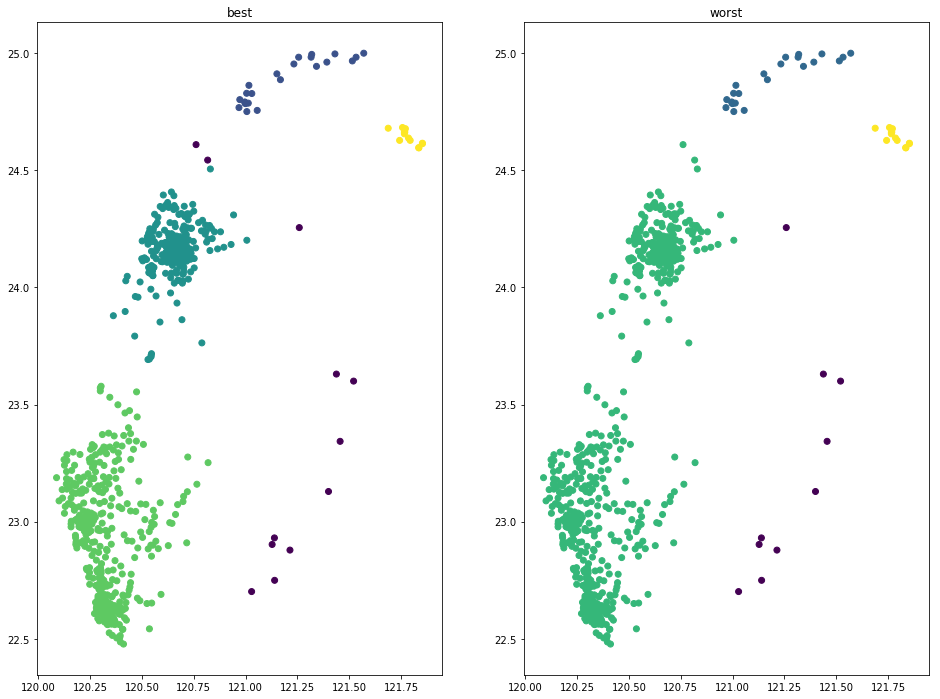

```
best:  0.734551138197
worst:  0.237191198194
```

```python
plt.figure(figsize=(16, 12))
BDSCAN1 = cluster.DBSCAN(eps = 0.2, min_samples = 10)
%time BDSCAN1.fit(df_location)
plt.subplot(121)
plt.scatter(df_location['lon'].values, df_location['lat'].values, c=BDSCAN1.labels_)
plt.title('best')

BDSCAN2 = cluster.DBSCAN(eps = 0.25, min_samples = 10)
%time BDSCAN2.fit(df_location)
plt.subplot(122)
plt.scatter(df_location['lon'].values, df_location['lat'].values, c=BDSCAN2.labels_)
plt.title('worst')
plt.show()
silhouette_avg1 = metrics.silhouette_score(df_location, BDSCAN1.labels_)
print('best: ',silhouette_avg1)
silhouette_avg2 = metrics.silhouette_score(df_location, BDSCAN2.labels_)
print('worst: ',silhouette_avg2)
```

### 討論

**表現**：

兩者在分群的表現上最佳程度都差不多，可以將肉眼觀察到的主要群分出來。

**個別討論**：

由於Kmeans是以距離做分群，因此可以發現在某些狀況下表現異常，如Kmeans右圖的右上角處明顯發現綠色和藍色的群沒有分得很好，也可以發現中部和南部的群硬被拆成2群和4群，與我們目標有落差。分群表現似乎與cluster數成反比。

DBSCAN是以密度做分群，在左圖中，群數更多但也分的很好，相較Kmeans若分成5群效果來得好。分群表現需要設定適當的eps才會優良，並不是越大越好或是越小越好。

# Task2 Spatial + PM2.5 Clustering:

### Kmeans , Date : 2017-03-10 , Time : 17:10:00

```python
df_pm_location = df2[(df2['Date']=='2017-03-10') & (df2['Time']=='17:10:00')].iloc[:,[3,8,9]]

#unity-based normalization [0,1]
df_norm = (df_pm_location-df_pm_location.min())/(df_pm_location.max()-df_pm_location.min())
```

兩組資料，分別是有無標準化，其標準化方法是unity-based normalization，其值介於0,1之間

```
CPU times: user 29.7 ms, sys: 2.32 ms, total: 32 ms
Wall time: 30.9 ms
CPU times: user 38.8 ms, sys: 206 µs, total: 39 ms
Wall time: 39.2 ms
```

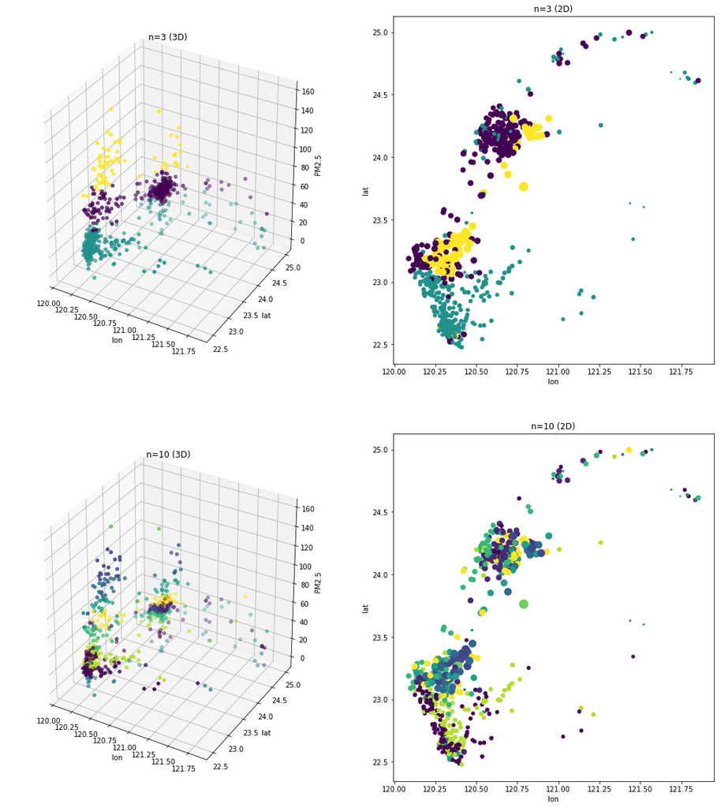

```python
%time kmeans1.fit(df_pm_location)
fig = plt.figure(figsize=(18, 20))
ax = fig.add_subplot(221, projection='3d')
ax.scatter(df_pm_location['lon'].values, df_pm_location['lat'].values, df_pm_location['PM2.5'].values, c=kmeans1.labels_)
ax.set_xlabel('lon')
ax.set_ylabel('lat')
ax.set_zlabel('PM2.5')
plt.title('n=3 (3D)')

plt.subplot(222)
plt.scatter(df_pm_location['lon'].values, df_pm_location['lat'].values, df_pm_location['PM2.5'].values, c=kmeans1.labels_)
plt.xlabel('lon')
plt.ylabel('lat')
plt.title('n=3 (2D)')

%time kmeans2.fit(df_pm_location)
ax = fig.add_subplot(223, projection='3d')
ax.scatter(df_pm_location['lon'].values, df_pm_location['lat'].values, df_pm_location['PM2.5'].values, c=kmeans2.labels_)
ax.set_xlabel('lon')
ax.set_ylabel('lat')
ax.set_zlabel('PM2.5')
plt.title('n=10 (3D)')

plt.subplot(224)
plt.scatter(df_pm_location['lon'].values, df_pm_location['lat'].values, df_pm_location['PM2.5'].values, c=kmeans2.labels_)
plt.xlabel('lon')
plt.ylabel('lat')
plt.title('n=10 (2D)')
plt.show()
```

左圖為三個分群因素的三圍座標圖，右圖為二維座標圖，圓圈越大代表pm2.5的值越大

上下分別是cluster數為3,10

```
CPU times: user 27 ms, sys: 2.08 ms, total: 29.1 ms
Wall time: 27.2 ms
CPU times: user 49.3 ms, sys: 89 µs, total: 49.4 ms
Wall time: 49.5 ms
```

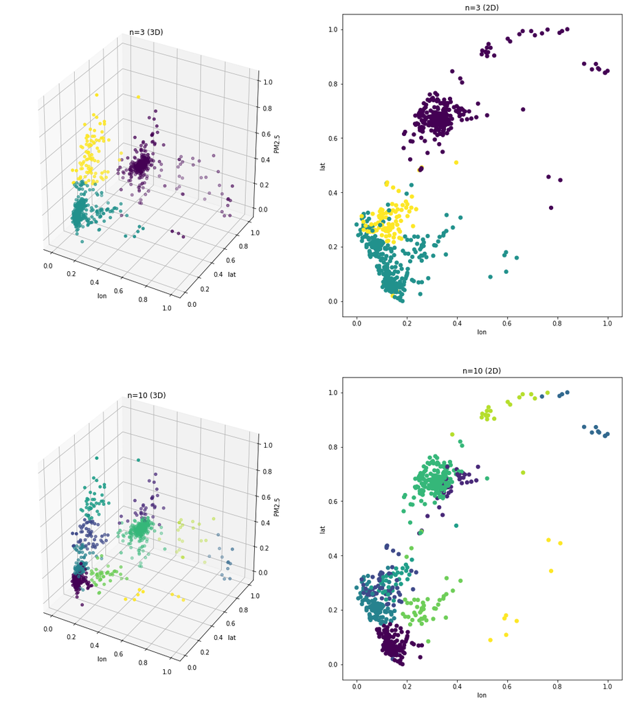

```python
%time kmeans1.fit(df_norm)
fig = plt.figure(figsize=(18, 20))
ax = fig.add_subplot(221, projection='3d')
ax.scatter(df_norm['lon'].values, df_norm['lat'].values, df_norm['PM2.5'].values, c=kmeans1.labels_)
ax.set_xlabel('lon')
ax.set_ylabel('lat')
ax.set_zlabel('PM2.5')
plt.title('n=3 (3D)')

plt.subplot(222)
plt.scatter(df_norm['lon'].values, df_norm['lat'].values, c=kmeans1.labels_)
plt.xlabel('lon')
plt.ylabel('lat')
plt.title('n=3 (2D)')

%time kmeans2.fit(df_norm)
ax = fig.add_subplot(223, projection='3d')
ax.scatter(df_norm['lon'].values, df_norm['lat'].values, df_norm['PM2.5'].values, c=kmeans2.labels_)
ax.set_xlabel('lon')
ax.set_ylabel('lat')
ax.set_zlabel('PM2.5')
plt.title('n=10 (3D)')

plt.subplot(224)
plt.scatter(df_norm['lon'].values, df_norm['lat'].values, c=kmeans2.labels_)
plt.xlabel('lon')
plt.ylabel('lat')
plt.title('n=10 (2D)')
plt.show()
```

### 討論

有無標準化，其運算時間差不多。在尚未標準化下，可以發現有雜亂的現象，並沒有完整的分群，其原因是在沒有標準化下，其值本身的大小會影響分群表現，但分群是根據其分佈做分類，也許某些間隔較遠的點因為其PM2.5的值較相近而主導了分群的過程，使這些點分為同一群，但在視覺上並沒有，如3D圖觀察到群依據z軸分成三塊。

然而經過標準化之後從3D圖可以觀察到分群表現優良，資料在3D圖中大致分成三群，標準化可以明顯的分成三群。

# Task3 Temporal Clustering:

### Agglomerative Clustering , Date : 2017-03-10

```python
tmp = df2[df2['Date']=='2017-03-10'].groupby('device_id').size().reset_index(name='count')
tmp = tmp[tmp['count']!=144]
tmp
```

|  | device_id | count |
| --- | --- | --- |
| 671 | 74DA38AF47C6 | 73 |

篩選未搜集144個時間的sensor

```python
df3 = df2[(df2['Date']=='2017-03-10') & (df2['device_id']!='74DA38AF47C6')].iloc[:,[2,3,8,9]]
device = np.array(['' for _ in range(755)], dtype='U12')
air = np.zeros(shape=(144,755))
location = np.zeros(shape=(2,755))

for i in range(755):
    j = i*144
    device[i] = df3['device_id'].values[j]
    location[0][i] = df3['lat'].values[j]
    location[1][i] = df3['lon'].values[j]

for i in range(144):
    for j in range(755):
        air[i][j] = df3['PM2.5'].values[j*144+i]

df_temporal = pd.DataFrame({'device_id': device, 'lat': location[0], 'lon': location[1]})
for i in range(144):
    df_temporal['PM2.5_'+str(i)] = air[i]
df_temporal
```

|  | device_id | lat | lon | PM2.5_0 | PM2.5_1 | PM2.5_2 | PM2.5_3 | PM2.5_4 | PM2.5_5 | PM2.5_6 | ... | PM2.5_134 | PM2.5_135 | PM2.5_136 | PM2.5_137 | PM2.5_138 | PM2.5_139 | PM2.5_140 | PM2.5_141 | PM2.5_142 | PM2.5_143 |
| --- | --- | --- | --- | --- | --- | --- | --- | --- | --- | --- | --- | --- | --- | --- | --- | --- | --- | --- | --- | --- | --- |
| 0 | 28C2DDDD459E | 24.961 | 121.392 | 19.0 | 19.0 | 18.0 | 18.0 | 18.0 | 18.0 | 15.0 | ... | 34.0 | 30.0 | 30.0 | 28.0 | 26.5 | 25.5 | 25.5 | 25.5 | 24.0 | 24.0 |
| 1 | 28C2DDDD45E6 | 24.158 | 120.675 | 28.0 | 30.0 | 31.0 | 36.0 | 43.0 | 43.0 | 42.0 | ... | 11.5 | 11.5 | 11.0 | 14.0 | 14.0 | 14.0 | 22.0 | 22.0 | 30.0 | 29.0 |
| 2 | 74DA388FF3AA | 24.943 | 121.342 | 18.0 | 17.0 | 17.0 | 17.0 | 16.0 | 16.0 | 16.0 | ... | 6.0 | 6.0 | 6.0 | 6.0 | 6.0 | 6.0 | 6.0 | 6.0 | 7.0 | 5.0 |
| 3 | 74DA388FF56C | 24.996 | 121.431 | 36.0 | 36.0 | 36.0 | 36.0 | 36.0 | 36.0 | 36.0 | ... | 10.0 | 7.0 | 7.0 | 3.5 | 4.0 | 4.0 | 3.0 | 3.0 | 3.0 | 3.0 |
| 4 | 74DA3895C1F8 | 24.149 | 120.681 | 98.0 | 91.0 | 92.0 | 95.0 | 96.0 | 98.0 | 94.0 | ... | 33.0 | 33.0 | 43.0 | 43.0 | 43.0 | 43.0 | 43.0 | 43.0 | 43.0 | 49.0 |
| 5 | 74DA3895C1FA | 24.188 | 120.595 | 78.0 | 81.0 | 80.0 | 83.0 | 88.0 | 90.0 | 89.0 | ... | 33.0 | 37.0 | 37.0 | 37.0 | 37.0 | 45.0 | 45.0 | 45.0 | 45.5 | 45.5 |
| 6 | 74DA3895C200 | 24.138 | 120.673 | 100.5 | 87.0 | 90.0 | 90.0 | 87.0 | 87.0 | 96.0 | ... | 39.0 | 39.0 | 39.0 | 44.0 | 44.0 | 44.0 | 52.0 | 52.0 | 52.0 | 50.0 |
| 7 | 74DA3895C204 | 24.151 | 120.665 | 70.0 | 70.0 | 70.0 | 70.0 | 70.0 | 74.0 | 74.0 | ... | 36.0 | 37.5 | 40.0 | 40.0 | 47.0 | 47.0 | 49.0 | 49.0 | 50.0 | 48.0 |
| 8 | 74DA3895C208 | 24.161 | 120.648 | 50.0 | 51.0 | 51.0 | 49.0 | 49.0 | 49.0 | 49.0 | ... | 49.0 | 49.0 | 49.0 | 49.0 | 49.0 | 49.0 | 49.0 | 49.0 | 49.0 | 49.0 |
| 9 | 74DA3895C20A | 24.167 | 120.692 | 53.0 | 53.0 | 51.0 | 50.0 | 50.0 | 50.0 | 49.0 | ... | 15.0 | 18.0 | 18.0 | 18.0 | 20.0 | 24.0 | 24.0 | 28.0 | 28.0 | 28.0 |
| 10 | 74DA3895C20C | 24.159 | 120.659 | 75.0 | 75.0 | 86.0 | 74.0 | 73.0 | 73.0 | 73.0 | ... | 22.0 | 33.0 | 36.0 | 39.0 | 41.5 | 41.5 | 41.0 | 41.0 | 41.0 | 42.0 |
| 11 | 74DA3895C210 | 24.188 | 120.702 | 86.0 | 88.0 | 81.5 | 81.5 | 80.5 | 79.0 | 79.0 | ... | 41.0 | 42.0 | 44.0 | 45.0 | 45.0 | 50.0 | 51.5 | 51.0 | 46.0 | 44.0 |
| 12 | 74DA3895C212 | 24.127 | 120.614 | 81.0 | 81.0 | 80.0 | 79.0 | 80.0 | 80.0 | 89.0 | ... | 31.0 | 31.0 | 34.0 | 36.0 | 40.0 | 40.0 | 40.0 | 48.0 | 48.0 | 48.0 |
| 13 | 74DA3895C214 | 24.115 | 120.631 | 89.0 | 89.0 | 97.0 | 98.0 | 98.0 | 95.0 | 93.5 | ... | 35.0 | 36.0 | 36.0 | 42.0 | 42.0 | 47.0 | 47.0 | 46.0 | 46.0 | 47.0 |
| 14 | 74DA3895C216 | 24.166 | 120.678 | 66.0 | 66.0 | 66.0 | 66.0 | 70.0 | 70.0 | 70.0 | ... | 27.0 | 27.0 | 27.0 | 27.0 | 27.0 | 27.0 | 27.0 | 27.0 | 27.0 | 40.0 |
| 15 | 74DA3895C218 | 24.136 | 120.665 | 58.0 | 58.0 | 58.0 | 58.0 | 58.0 | 58.0 | 54.0 | ... | 19.5 | 16.0 | 18.0 | 18.0 | 20.0 | 23.5 | 27.0 | 27.0 | 28.0 | 33.0 |
| 16 | 74DA3895C21E | 24.191 | 120.612 | 55.0 | 55.0 | 53.5 | 51.0 | 49.5 | 49.5 | 48.0 | ... | 22.0 | 25.0 | 28.0 | 26.0 | 26.0 | 26.0 | 26.0 | 42.0 | 41.0 | 43.0 |
| 17 | 74DA3895C222 | 24.184 | 120.602 | 103.5 | 120.0 | 116.0 | 116.0 | 99.0 | 96.5 | 98.0 | ... | 31.0 | 33.5 | 33.5 | 39.0 | 42.5 | 43.0 | 43.0 | 45.0 | 44.0 | 44.0 |
| 18 | 74DA3895C224 | 24.136 | 120.635 | 82.0 | 82.0 | 82.0 | 82.0 | 82.0 | 82.0 | 82.0 | ... | 37.0 | 36.0 | 39.0 | 41.5 | 45.0 | 45.0 | 45.0 | 46.0 | 48.0 | 48.0 |
| 19 | 74DA3895C226 | 24.135 | 120.657 | 65.0 | 65.0 | 65.0 | 69.0 | 69.0 | 69.0 | 68.0 | ... | 22.0 | 22.0 | 29.0 | 29.0 | 29.0 | 39.0 | 39.0 | 39.0 | 39.0 | 38.0 |
| 20 | 74DA3895C228 | 24.135 | 120.678 | 59.0 | 59.0 | 59.0 | 59.0 | 59.0 | 59.0 | 59.0 | ... | 24.0 | 24.0 | 24.0 | 24.0 | 24.0 | 24.0 | 24.0 | 36.0 | 36.0 | 36.0 |
| 21 | 74DA3895C22C | 24.110 | 120.639 | 92.0 | 92.0 | 107.0 | 107.0 | 107.0 | 106.0 | 105.0 | ... | 36.0 | 36.0 | 41.0 | 45.0 | 45.5 | 47.0 | 50.0 | 50.0 | 49.0 | 49.0 |
| 22 | 74DA3895C230 | 24.147 | 120.638 | 72.0 | 71.0 | 71.0 | 75.0 | 75.0 | 73.0 | 73.0 | ... | 52.0 | 52.0 | 52.0 | 52.0 | 52.0 | 52.0 | 52.0 | 52.0 | 52.0 | 52.0 |
| 23 | 74DA3895C232 | 24.108 | 120.640 | 73.0 | 73.0 | 73.0 | 81.5 | 80.0 | 79.0 | 79.0 | ... | 26.0 | 31.0 | 31.0 | 36.0 | 36.0 | 36.0 | 36.0 | 36.0 | 36.0 | 36.0 |
| 24 | 74DA3895C234 | 24.244 | 120.609 | 45.5 | 45.5 | 45.5 | 45.5 | 45.5 | 45.5 | 45.5 | ... | 60.0 | 60.0 | 60.0 | 60.0 | 60.0 | 72.0 | 72.0 | 72.0 | 74.0 | 74.0 |
| 25 | 74DA3895C23E | 24.110 | 120.593 | 51.0 | 51.0 | 51.0 | 52.0 | 52.0 | 52.0 | 52.0 | ... | 43.0 | 43.0 | 41.0 | 42.0 | 42.5 | 42.5 | 42.5 | 42.5 | 42.5 | 42.5 |
| 26 | 74DA3895C240 | 24.243 | 120.542 | 70.5 | 71.0 | 71.0 | 71.0 | 71.0 | 71.0 | 74.0 | ... | 33.0 | 33.0 | 33.0 | 33.0 | 33.0 | 40.0 | 40.0 | 40.0 | 40.0 | 40.0 |
| 27 | 74DA3895C246 | 24.229 | 120.532 | 89.0 | 86.0 | 86.0 | 81.0 | 81.0 | 80.0 | 82.0 | ... | 35.0 | 35.0 | 35.0 | 35.0 | 45.0 | 45.0 | 45.0 | 47.0 | 47.0 | 47.0 |
| 28 | 74DA3895C248 | 24.235 | 120.535 | 81.0 | 81.0 | 85.0 | 85.0 | 84.0 | 86.0 | 89.0 | ... | 35.0 | 39.0 | 41.0 | 42.0 | 42.0 | 42.0 | 42.0 | 42.0 | 42.0 | 42.0 |
| 29 | 74DA3895C24A | 24.239 | 120.554 | 85.0 | 84.0 | 84.0 | 84.0 | 83.0 | 91.0 | 91.0 | ... | 39.0 | 40.5 | 42.0 | 44.0 | 45.0 | 47.0 | 49.0 | 49.0 | 49.0 | 49.0 |
| ... | ... | ... | ... | ... | ... | ... | ... | ... | ... | ... | ... | ... | ... | ... | ... | ... | ... | ... | ... | ... | ... |
| 725 | 74DA38AF48AC | 22.541 | 120.406 | 21.0 | 21.0 | 17.0 | 16.0 | 17.0 | 17.0 | 19.0 | ... | 25.0 | 25.0 | 25.0 | 25.0 | 25.0 | 46.0 | 46.0 | 46.0 | 39.0 | 36.0 |
| 726 | 74DA38AF48B2 | 24.240 | 120.797 | 69.0 | 68.0 | 68.0 | 63.0 | 60.5 | 60.5 | 60.5 | ... | 40.5 | 40.5 | 37.0 | 37.0 | 37.0 | 37.0 | 37.0 | 38.0 | 38.0 | 37.0 |
| 727 | 74DA38AF48B4 | 24.827 | 121.030 | 16.0 | 16.0 | 18.0 | 17.0 | 18.0 | 19.0 | 17.0 | ... | 5.5 | 6.0 | 6.0 | 6.0 | 5.0 | 6.0 | 6.0 | 5.0 | 4.0 | 4.0 |
| 728 | 74DA38AF48B6 | 24.953 | 121.233 | 30.0 | 25.0 | 24.0 | 22.0 | 23.0 | 22.5 | 21.5 | ... | 16.0 | 23.5 | 23.0 | 23.0 | 20.0 | 20.0 | 20.5 | 20.5 | 20.0 | 20.0 |
| 729 | 74DA38AF48BC | 24.050 | 120.553 | 86.5 | 84.0 | 84.0 | 82.0 | 85.0 | 84.0 | 84.0 | ... | 21.0 | 28.0 | 31.0 | 31.0 | 33.0 | 33.0 | 33.0 | 38.0 | 44.0 | 44.0 |
| 730 | 74DA38AF48BE | 24.183 | 120.674 | 84.0 | 81.5 | 81.0 | 81.0 | 81.0 | 81.0 | 81.0 | ... | 34.5 | 34.5 | 34.5 | 34.5 | 46.0 | 46.0 | 46.0 | 46.0 | 46.0 | 46.0 |
| 731 | 74DA38AF48C0 | 24.613 | 121.853 | 75.0 | 80.5 | 93.0 | 91.0 | 104.0 | 100.0 | 100.0 | ... | 57.0 | 52.0 | 55.0 | 55.0 | 55.0 | 55.0 | 40.0 | 40.0 | 40.0 | 39.5 |
| 732 | 74DA38AF48C2 | 24.023 | 120.491 | 67.5 | 67.5 | 67.5 | 75.0 | 73.0 | 64.0 | 70.0 | ... | 28.0 | 28.0 | 34.0 | 37.0 | 40.0 | 40.0 | 42.0 | 44.0 | 44.0 | 44.0 |
| 733 | 74DA38AF48C6 | 24.085 | 120.532 | 71.0 | 71.0 | 69.0 | 74.0 | 74.0 | 75.0 | 76.0 | ... | 24.0 | 27.0 | 30.0 | 34.0 | 34.0 | 34.0 | 40.5 | 41.0 | 42.0 | 43.0 |
| 734 | 74DA38AF48CA | 22.987 | 120.206 | 81.0 | 82.0 | 82.0 | 79.5 | 76.0 | 76.0 | 76.5 | ... | 39.0 | 44.0 | 44.0 | 46.0 | 41.5 | 39.0 | 38.0 | 38.5 | 38.5 | 38.5 |
| 735 | 74DA38AF48DA | 23.183 | 120.254 | 55.0 | 56.0 | 56.0 | 56.0 | 59.0 | 59.0 | 61.0 | ... | 37.0 | 37.0 | 37.0 | 35.0 | 35.0 | 34.0 | 33.0 | 33.0 | 33.0 | 29.0 |
| 736 | 74DA38AF48DC | 23.012 | 120.187 | 24.0 | 33.0 | 33.0 | 24.0 | 21.0 | 21.0 | 12.0 | ... | 11.0 | 8.5 | 9.0 | 9.0 | 9.0 | 9.0 | 9.0 | 10.0 | 10.0 | 10.0 |
| 737 | 74DA38AF48E2 | 22.804 | 120.300 | 60.0 | 60.0 | 60.0 | 62.0 | 64.0 | 64.5 | 64.0 | ... | 61.0 | 58.0 | 56.0 | 54.0 | 52.5 | 52.5 | 51.0 | 51.0 | 51.0 | 52.0 |
| 738 | 74DA38AF48F4 | 23.131 | 120.200 | 36.0 | 36.0 | 36.0 | 36.0 | 38.0 | 38.5 | 38.0 | ... | 31.0 | 31.0 | 30.0 | 30.0 | 30.0 | 30.0 | 30.0 | 30.0 | 30.0 | 30.0 |
| 739 | 74DA38AF48F8 | 24.083 | 120.554 | 56.0 | 56.5 | 61.0 | 61.0 | 59.0 | 63.0 | 61.0 | ... | 27.5 | 30.0 | 28.0 | 28.0 | 28.0 | 28.0 | 27.5 | 31.0 | 31.0 | 32.0 |
| 740 | 74DA38AF48FA | 24.161 | 120.734 | 61.0 | 62.0 | 58.0 | 58.5 | 58.5 | 56.5 | 51.5 | ... | 33.0 | 39.0 | 39.0 | 39.0 | 39.0 | 39.0 | 41.0 | 41.0 | 41.0 | 41.0 |
| 741 | 74DA38AF48FC | 24.505 | 120.830 | 56.5 | 55.0 | 52.0 | 51.0 | 51.0 | 50.0 | 53.0 | ... | 41.0 | 33.5 | 28.0 | 30.0 | 30.0 | 34.5 | 34.5 | 33.0 | 33.0 | 33.0 |
| 742 | 74DA38AF48FE | 24.161 | 120.731 | 80.0 | 80.0 | 80.0 | 78.0 | 78.0 | 81.0 | 74.5 | ... | 39.0 | 39.0 | 51.0 | 51.0 | 46.0 | 46.0 | 47.0 | 124.0 | 48.0 | 47.0 |
| 743 | 74DA38AF4908 | 24.163 | 120.681 | 30.0 | 31.5 | 30.0 | 31.0 | 32.0 | 31.0 | 34.0 | ... | 8.5 | 8.0 | 7.0 | 7.0 | 7.0 | 7.0 | 7.0 | 7.0 | 7.0 | 7.0 |
| 744 | 74DA38AF490E | 22.690 | 120.592 | 80.0 | 80.0 | 80.0 | 80.0 | 84.0 | 84.0 | 82.0 | ... | 75.5 | 70.5 | 71.0 | 71.0 | 71.0 | 71.0 | 71.0 | 105.0 | 100.0 | 100.0 |
| 745 | 74DA38AF4928 | 23.185 | 120.374 | 77.0 | 71.0 | 71.0 | 71.0 | 63.0 | 62.0 | 58.0 | ... | 50.0 | 51.0 | 51.0 | 49.0 | 46.5 | 46.5 | 46.5 | 44.0 | 43.5 | 43.5 |
| 746 | 74DA38AF492C | 23.558 | 120.299 | 100.0 | 98.0 | 96.0 | 96.0 | 96.0 | 103.0 | 103.0 | ... | 39.0 | 34.0 | 36.0 | 36.0 | 39.0 | 44.0 | 45.0 | 44.0 | 44.0 | 44.0 |
| 747 | 74DA38AF493E | 22.962 | 120.231 | 81.0 | 80.5 | 80.5 | 84.0 | 83.5 | 83.5 | 83.5 | ... | 44.0 | 46.0 | 48.0 | 48.0 | 48.0 | 46.0 | 40.0 | 41.0 | 41.0 | 40.0 |
| 748 | 74DA38AF4944 | 24.828 | 121.005 | 43.0 | 43.0 | 43.0 | 43.0 | 43.0 | 43.5 | 44.0 | ... | 15.0 | 15.0 | 13.5 | 13.5 | 13.5 | 6.0 | 7.0 | 7.0 | 11.0 | 12.0 |
| 749 | 74DA38AF4946 | 22.992 | 120.198 | 68.0 | 68.0 | 70.0 | 70.0 | 70.0 | 69.0 | 69.0 | ... | 33.5 | 33.0 | 33.0 | 34.0 | 34.0 | 34.0 | 32.0 | 32.0 | 32.0 | 30.0 |
| 750 | 74DA38AF4948 | 24.755 | 121.056 | 46.0 | 46.0 | 50.5 | 49.0 | 47.0 | 45.0 | 45.0 | ... | 15.0 | 15.0 | 15.0 | 15.0 | 25.0 | 28.5 | 26.0 | 26.0 | 16.5 | 16.5 |
| 751 | 74DA38AF4950 | 23.958 | 120.481 | 42.5 | 42.5 | 43.0 | 43.0 | 43.0 | 43.0 | 44.0 | ... | 7.0 | 7.0 | 6.5 | 6.5 | 8.0 | 8.0 | 10.0 | 10.0 | 12.0 | 12.0 |
| 752 | 74DA38AF4954 | 24.130 | 120.667 | 57.0 | 57.0 | 73.0 | 78.0 | 85.0 | 87.5 | 87.5 | ... | 34.0 | 34.5 | 34.5 | 34.0 | 37.5 | 37.5 | 37.5 | 41.5 | 41.5 | 39.0 |
| 753 | 74DA38AF4956 | 22.662 | 120.299 | 40.0 | 43.0 | 46.0 | 46.0 | 46.5 | 46.0 | 46.0 | ... | 46.5 | 45.0 | 44.0 | 44.0 | 44.0 | 43.0 | 42.0 | 42.0 | 42.0 | 41.0 |
| 754 | 74DA38AF4958 | 24.184 | 120.610 | 74.0 | 74.0 | 74.0 | 77.0 | 77.0 | 77.0 | 77.0 | ... | 38.0 | 40.0 | 42.0 | 42.0 | 42.0 | 48.0 | 48.5 | 48.5 | 48.5 | 47.5 |

755 rows × 147 columns

```
CPU times: user 70.4 ms, sys: 7.1 ms, total: 77.5 ms
Wall time: 77.6 ms
CPU times: user 10.9 ms, sys: 1.3 ms, total: 12.2 ms
Wall time: 12.3 ms
```

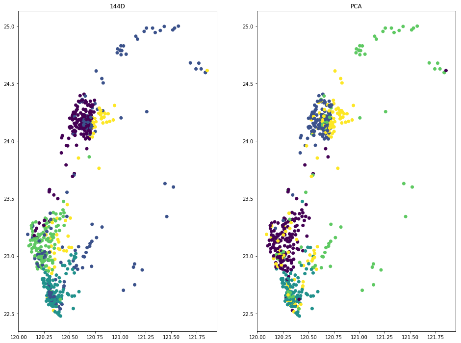

```
144D:  0.203895988403
PCA:  0.157240982754
```

```python
plt.figure(figsize=(16, 12))
agglo1 = cluster.AgglomerativeClustering(n_clusters=5)
%time agglo1.fit(df_temporal.iloc[:,3:-1])
labels_ori = agglo1.labels_
plt.subplot(121)
plt.scatter(location[1], location[0], c=agglo1.labels_)
plt.title('144D')
silhouette_avg1 = metrics.silhouette_score(df_temporal.iloc[:,1:3], agglo1.labels_)

reduced_data = decomposition.PCA(n_components=9).fit_transform(df_temporal.iloc[:,3:-1])
%time agglo1.fit(reduced_data)
plt.subplot(122)
labels_pca = agglo1.labels_
plt.scatter(location[1], location[0], c=agglo1.labels_)
plt.title('PCA')
plt.show()

silhouette_avg2 = metrics.silhouette_score(df_temporal.iloc[:,1:3], agglo1.labels_)
print('144D: ',silhouette_avg1)
print('PCA: ',silhouette_avg2)
```

左圖為144維資料，右圖經過PCA降維後的資料，下面是此兩者分群結果與地理位置的相關值

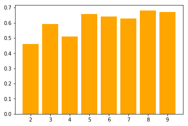

```
[0.46029607352555862, 0.5932787364680504, 0.51006477010828111, 0.65702890994768282, 0.6421115214198212, 0.62904510705528915, 0.68159814560281529, 0.67040047864652663]
```

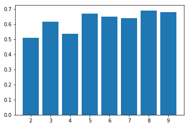

```
[0.50908581137337228, 0.61629909960257401, 0.53485178484257023, 0.66832278003047552, 0.64982142211483074, 0.63874246608120977, 0.69082132036877408, 0.68105990992898824]
```

```python
num_cluster = range(2,10)
ami = []
nmi = []
for i in num_cluster:
    agglo = cluster.AgglomerativeClustering(n_clusters=i)
    agglo.fit(df_temporal.iloc[:,3:-1])
    labels_ori = agglo.labels_
    reduced_data = decomposition.PCA(n_components=9).fit_transform(df_temporal.iloc[:,3:-1])
    agglo.fit(reduced_data)
    labels_pca = agglo.labels_
    ami.append(metrics.adjusted_mutual_info_score(labels_ori, labels_pca))
    nmi.append(metrics.normalized_mutual_info_score(labels_ori, labels_pca))

plt.bar(num_cluster, ami, color='orange')
plt.show()
print(ami)
plt.bar(num_cluster, nmi)
plt.show()
print(nmi)
```

Normalized Mutual Information(NMI)和Adjusted Mutual Information(AMI)為評估分群表現的指數，如先前的Silhouette Score。在這裡我用來測試144d和經過PCA的兩個結果的相似程度。

此部分是觀察cluster數的影響程度。橘色為AMI,藍色為NMI。

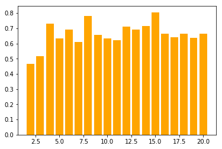

[output not shown]

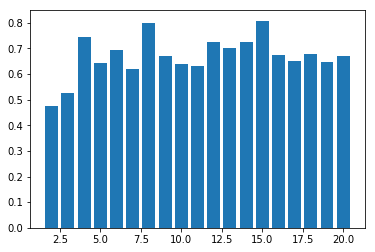

[output not shown]

```python
num_component = range(2,21)
ami = []
nmi = []
for i in num_component:
    agglo = cluster.AgglomerativeClustering(n_clusters=5)
    agglo.fit(df_temporal.iloc[:,3:-1])
    labels_ori = agglo.labels_
    reduced_data = decomposition.PCA(n_components=i).fit_transform(df_temporal.iloc[:,3:-1])
    agglo.fit(reduced_data)
    labels_pca = agglo.labels_
    ami.append(metrics.adjusted_mutual_info_score(labels_ori, labels_pca))
    nmi.append(metrics.normalized_mutual_info_score(labels_ori, labels_pca))
plt.bar(num_component, ami, color='orange')
plt.show()
print(ami)
plt.bar(num_component, nmi)
plt.show()
print(nmi)
```

此部分是觀察PCA的component數影響分群程度。

### 討論

此task分群依據當日每個sensor的空氣浮動趨勢和數值做分群。我將結果顯示在地圖上，沒有座標資訊但是此分群仍然可以對應到地圖上分群，顯示空氣品質和變化跟地理位址是有相當大的關係。

經過PCA處理後分群運算時間減少了84%左右，因此我想比較得到時間利益的情況下，分群表現是否有所變化，雖然AMI和NMI原本是測試與true label的相異程度，但我將144d作為true label來比較PCA後的表現，不同的cluster數會有影響，大致在50%~70%之間，在cluster=2最差，cluster=8最佳。接下來PCA中不同的component數也會影響，選擇不適當的數量可能低於50%，適當的數量竟然可能到達80%，結論如果做好的PCA不但可以大幅下降運算時間，在分群表現上也不會與PCA前相差太遠。

# Task4 Others:

### 觀察空氣品質、溫度、濕度對於地理位置的相關性

### Kmeans , Date : 2017-03-10 , Time : 17:10:00

首先將資料抽出並標準化

```python
df_loc = df2[(df2['Date']=='2017-03-10') & (df2['Time']=='17:10:00')].iloc[:,[8,9]]
df_temperature = df2[(df2['Date']=='2017-03-10') & (df2['Time']=='17:10:00')].iloc[:,[6]]
#unity-based normalization [0,1]
df_norm_temp = (df_temperature-df_temperature.min())/(df_temperature.max()-df_temperature.min())

df_humidity = df2[(df2['Date']=='2017-03-10') & (df2['Time']=='17:10:00')].iloc[:,[7]]
#unity-based normalization [0,1]
df_norm_hum = (df_humidity-df_humidity.min())/(df_humidity.max()-df_humidity.min())

df_all = df2[(df2['Date']=='2017-03-10') & (df2['Time']=='17:10:00')].iloc[:,[3,6,7]]
#unity-based normalization [0,1]
df_norm_all = (df_all-df_all.min())/(df_all.max()-df_all.min())
```

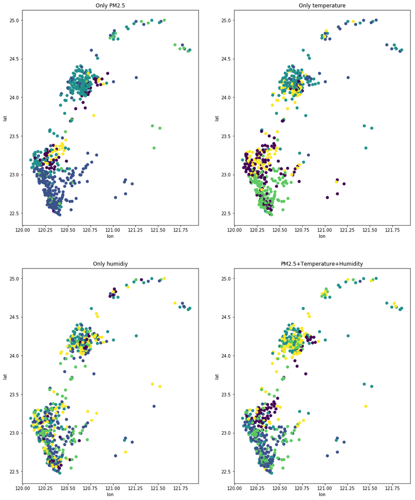

```python
kmeans4 = cluster.KMeans(n_clusters = 5, random_state = 0)
kmeans4.fit(df_norm.iloc[:,0:1])
label_pm = kmeans4.labels_
plt.figure(figsize=(16, 20))
plt.subplot(221)
plt.scatter(df_loc['lon'].values, df_loc['lat'].values, c=label_pm)
plt.xlabel('lon')
plt.ylabel('lat')
plt.title('Only PM2.5')

kmeans4.fit(df_norm_temp)
label_temp = kmeans4.labels_
plt.subplot(222)
plt.scatter(df_loc['lon'].values, df_loc['lat'].values, c=label_temp)
plt.xlabel('lon')
plt.ylabel('lat')
plt.title('Only temperature')

kmeans4.fit(df_norm_hum)
label_hum = kmeans4.labels_
plt.subplot(223)
plt.scatter(df_loc['lon'].values, df_loc['lat'].values, c=label_hum)
plt.xlabel('lon')
plt.ylabel('lat')
plt.title('Only humidiy')

kmeans4.fit(df_norm_all)
label_all = kmeans4.labels_
plt.subplot(224)
plt.scatter(df_loc['lon'].values, df_loc['lat'].values, c=label_all)
plt.xlabel('lon')
plt.ylabel('lat')
plt.title('PM2.5+Temperature+Humidity')

plt.show()
```

四張圖為分別只有某個因素做分群和三個因素一起參考做分群，並將結果對應到地理位置上。

```python
kmeans1.fit(df_loc)
label_location = kmeans1.labels_
metrics.adjusted_mutual_info_score(label_location, label_pm)
```

```
0.22264944767692713
```

此為空氣跟以地理資料做分群的結果比較

```python
metrics.adjusted_mutual_info_score(label_location, label_temp)
```

```
0.28058675407633832
```

此為溫度跟以地理資料做分群的結果比較

```python
metrics.adjusted_mutual_info_score(label_location, label_hum)
```

```
0.0098065242438144032
```

此為濕度跟以地理資料做分群的結果比較

```python
metrics.adjusted_mutual_info_score(label_location, label_all)
```

```
0.16498752403987407
```

此為三者皆考慮的結果跟以地理資料做分群的結果比較

### 討論

根據三者因素的AMI來看，溫度與地理關係最高，其次是空氣品質，最後是濕度。

觀察圖片可以發現空氣品質的分群是每個群幾乎都有延伸到最北和最南，有長條型群的趨勢，在高雄屏東也有一個明顯的群，推測空氣品質可以越靠近西部沿海會有變好或變糟的情況（由於光從圖片無法得知趨勢），越往南部也有類似的情況。然而溫度更為明顯，是以橫切的方式分群，跟越往北越冷的地理特徵符合。至於濕度非常混雜，可能跟地理沒有明顯關係。

然而在這個分析中，如果sensor密集分佈太廣就會蒐集到不同地理環境的資料，例如在圖片可以明顯看出主要分成三群（北中南），但由於中部和南部分佈太廣，因此在空氣和溫度分析中才會被拆成不同的群，因此在AMI中普遍不高，如果是有多個群到處分布（例如個縣市有一群sensor鄰近），也許可以更符合觀察。